# P160B131: R Laboratorinis darbas

Laboratorinio darbo tikslas - patikrinti žinias, įgytas **P160B131 Programavimas duomenų tvarkymui ir vizualizavimui** modulyje.

# Laboratorinio darbo vertinimas

- Duomenų importavimas (1 taškas)
- Duomenų vizualizacija (plot, geom_point, geom_bar) (3 taškai)
- R Shiny aplikacija (3 taškai)
- R Shiny aplikacijos veikimas dėstytojo kompiuteryje (1 taškas)
- Repositorija atitinka nurodytus reikalavimus (2 taškai)

+1 papildomas taškas prie laboratorinio darbo įvertinimo pridedamas už išvadų pateikimą ir/arba savo dizainu/funkcionalumu išsiskiriančią R Shiny aplikaciją.

# Reikalavimai atsiskaitymui

- sukurta github repositorija (fork iš https://github.com/kestutisd/KTU-duomenu-vizualizacija)
- pateiktas R scriptas pavadinimu **lab.R** dikrektorijoje **laboratorinis/R**
- duomenys - naudojamas failas iš **laboratorinis/data** katalogo
- grafikai - **laboratorinis/img** kataloge
- R Shiny aplikacija - **laboratorinis/app** kataloge (gali būti 1 (app.R) arba 2 (ui.R ir server.R) failai)
- Suformuotas **laboratorinis/readme.md** failas su grafikais ir shiny R aplikacijos “screenshot’u”
- Analizės išvados (jeigu yra) pateikiamos **laboratorinis/readme.md** faile

# Laboratorinio darbo užduotis

## Laboratorinio darbo variantai

Laboratoriniame darbe kiekvienam studentui yra atsitiktiniu būdu priskirtas ekonominės veiklos kodas, pagal kurį reikės atsifiltruoti duomenis.

| studento_numeris | ecoActCode |
| --- | --- |
| 1 | 731100 |
| 2 | 682000 |
| 3 | 479100 |
| 4 | 453200 |
| 5 | 862300 |
| 6 | 494100 |
| 7 | 452000 |
| 8 | 412000 |
| 9 | 702200 |
| 10 | 467300 |
| 11 | 561000 |
| 12 | 949900 |
| 13 | 522920 |
| 14 | 960900 |
| 15 | 692000 |
| 16 | 471100 |
| 17 | 451100 |

Duomenų profilis:

|  | code | jarCode | name | municipality | ecoActCode |
| --- | --- | --- | --- | --- | --- |
|  | Min. : 107 | Min. :110003978 | Length:314979 | Length:314979 | Min. :412000 |
|  | 1st Qu.: 410469 | 1st Qu.:151141178 | Class :character | Class :character | 1st Qu.:471100 |
|  | Median : 892465 | Median :300601491 | Mode :character | Mode :character | Median :561000 |
|  | Mean :1267293 | Mean :240200863 | NA | NA | Mean :641695 |
|  | 3rd Qu.:2188788 | 3rd Qu.:302909580 | NA | NA | 3rd Qu.:731100 |
|  | Max. :3422821 | Max. :305145928 | NA | NA | Max. :960900 |

|  | ecoActName | month | avgWage | numInsured | tax |
| --- | --- | --- | --- | --- | --- |
|  | Length:314979 | Min. :202001 | Min. : 3.58 | Min. : 0.000 | Min. : 3.2 |
|  | Class :character | 1st Qu.:202003 | 1st Qu.: 527.50 | 1st Qu.: 2.000 | 1st Qu.: 672.7 |
|  | Mode :character | Median :202006 | Median : 704.07 | Median : 3.000 | Median : 1280.5 |
|  | NA | Mean :202006 | Mean : 846.81 | Mean : 9.779 | Mean : 5068.6 |
|  | NA | 3rd Qu.:202009 | 3rd Qu.: 971.00 | 3rd Qu.: 6.000 | 3rd Qu.: 2994.4 |
|  | NA | Max. :202012 | Max. :25509.31 | Max. :13620.000 | Max. :2983081.9 |
|  | NA | NA | NA’s :189991 | NA | NA’s :189949 |

## 1 Užduotis

Atfiltravę duomenis pagal priskirtą ekonominės veiklos kodą, nubrėžkite histogramą vidutiniam atlyginimui. Galite naudoti base funkciją arba ggplot.

ggplot pavyzdys:

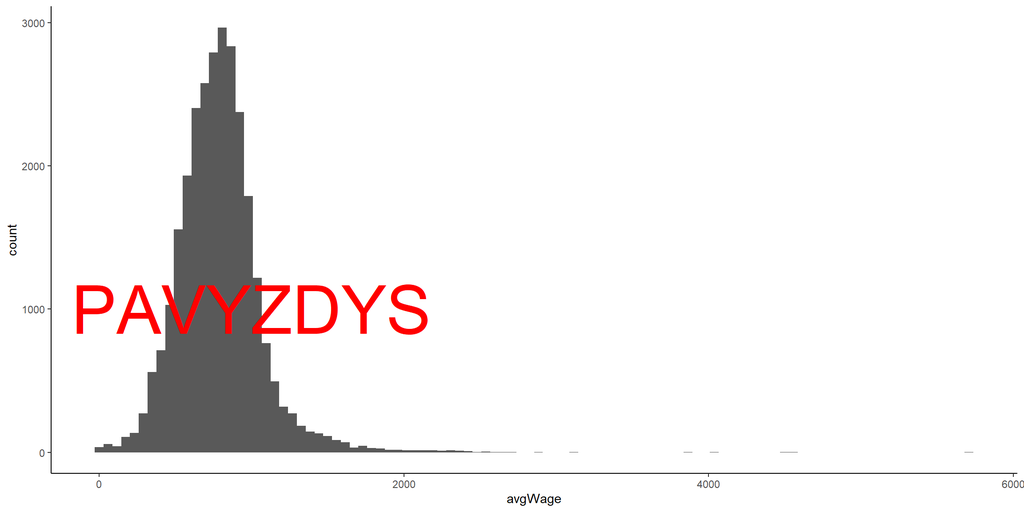

base pavyzdys:

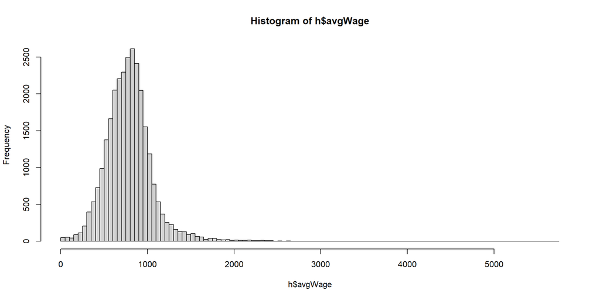

## 2 Užduotis

Išrinkite 5 įmones, kurių vidutinis darbo užmokestis buvo didžiausias pagal nurodytą veiklos sritį. Atvaizduokite šių įmonių vidutinio atlyginimo kitimo dinamiką metų eigoje.

Pavyzdys:

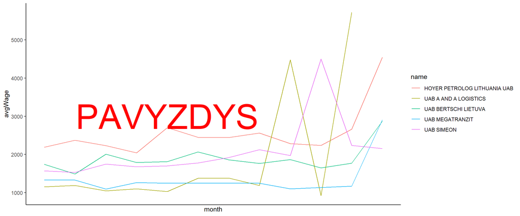

## 3 Užduotis

Iš anksčiau išrinktų 5 įmonių, išrinkite maksimalų apdraustų darbuotojų skaičių per šiuos metus. Atvaizduokite stulpeline diagrama mažėjimo tvarka.

Pavyzdys:

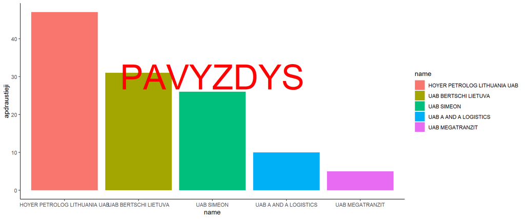

Pateiktą kodą išsaugokite **r-lab.R** vardu projekto “laboratorinis/R” direktorijoje.

## 4 Užduotis

Sukurkite web aplikaciją pagal nurodytą veiklos sritį.

Aplikacijos tikslas - vizualizuoti atlyginimų dinamiką (plotOutput) ir papildomus įmonės duomenis lentelėje, įvedus įmonės kodą.

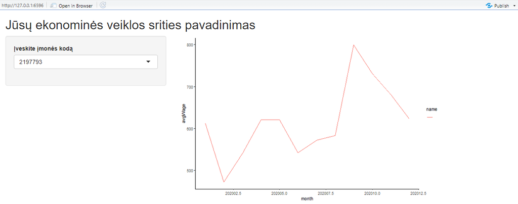

R Shiny aplikacijos pavyzdys